# Introduction to Probability

# What is probability theory?

## Probability

**Probability theory** is the quantitative, mathematical analysis of random processes.

We have already discussed two random processes:

1. Random sampling from a population
2. Random assignment to treatment and control groups

Helps us quantify the probability that random processes will give us the “wrong answer,” which helps us to:

1. Design better sampling schemes and experimental designs
2. Understand the limits of what we can know from given data

## Probability and Events

**Definition: Event**

An **event** is anything we can ask about the probability of. For example, in the following hypothetical questions, the event is shown in bold:

- “What is the probability that **the Milwaukee Brewers win the World Series**?”
- “What is the probability that **we get 10 heads in a row when flipping a coin**?”
- “What is the probability that **a simple random sample of Wake Forest students contains all freshmen**?”

Just like we denote variables in algebra with letters like $x$ or $y$, we denote abstract events with capital letters towards the beginning of the alphabet like $A$ or $B$.

## Probability Notation

Events are often defined using braces, so for example we might define the event $A$ as:

$$A =\{\text{7 heads in 10 flips of a coin}\}$$

Then the notation $P(A)$ is read as “the probability of $A$”.

## Making Probability Precise

Suppose we roll two dice and ask for the probability that the two numbers we get add up to 6.

How could we estimate this probability?

One possibility: Roll two dice 100 times and count how many times the sum is 6.

If we get a sum of 6 $k$ times, then we can estimate

$$P(\text{Two dice sum to 6}) \approx \frac{k}{100}$$

## Making Probability Precise

**Discussion Question**

What should we do if we want to improve the accuracy of our estimated probability?

**Answer:** We can roll the two dice more times.

**Discussion Question**

What do you think will happen to our estimate as we repeat the process of rolling the two dice more times?

**Answer:** It will get closer and closer to the true probability.

## Making Probability Precise

**Definition: The Law of Large Numbers**

The **Law of Large Numbers** states that, if we repeat a process many times and count the proportion of times that an outcome happens, that proportion converges to the probability of the outcome as the number of repetitions increases.

In the previous example:

- Rolling two dice was the **process**.
- Getting the sum of the two dice to be 6 was the **outcome**.

The law of large numbers tells us how we can relate mathematical statements about probabilities to the real world.

# The Logic of Probability

## Calculating Probabilities in Practice

In practice, repeating a process, e.g., 10,000 times is impractical and usually unnecessary.

Instead we calculate probabilities using **rules and formulas**.

But for calculations to be possible, we have to make **assumptions**.

**Discussion Question**

What is the probability that you get two heads when you flip two coins?

What assumption are you making when you answer this question?

## A Note on Assumptions

When making assumptions, it is useful to keep in mind that:

1. Almost all assumptions are at least somewhat incorrect
2. Some assumptions are *much* more reasonable than others

Example: Assuming a coin has equal probability of giving heads or tails is almost always reasonable, but… [not exactly correct](https://www.scientificamerican.com/article/scientists-destroy-illusion-that-coin-toss-flips-are-50-50/).

## Vocabulary: Disjoint Events

**Definition: Disjoint Events**

Two events $A$ and $B$ are said to be **disjoint** if it is impossible for them to both happen. For example, the following pairs of events are disjoint:

- $A=\{\text{The Brewers win the World Series}\}$ and $B=\{\text{The Dodgers win the World Series}\}$.
- $A=\{\text{You roll two dice and the sum is 5}\}$ and $B=\{\text{You roll two dice and both numbers are odd}\}$.

If we have more than two events, $A_1, A_2, \ldots, A_k$, then we say all of these events are disjoint if every pair is disjoint.

## A Common Assumption

One common assumption in probability is that:

1. We have a sequence of disjoint events $A_1,A_2,\ldots, A_k$.
2. These events are *exhaustive*: At least one must happen.
3. These events are *equiprobable*: They all have the same probability.

In this case we can conclude that $P(A_i) = 1/k$ for all $i=1,2,\ldots,k$.

## Equiprobable, Exhaustive Events

Examples:

1. Rolling a die, $k=6$,  
   $A_i = \{\text{Roll number } i\}$
2. Flipping a coin, $k=2$,  
   $A_1 = \{\text{Get heads}\}$, $A_2 = \{\text{Get tails}\}$
3. Flipping 2 coins, $k=4$,  
   $A_1 = \{\text{HH}\}$, $A_2 = \{\text{TH}\}$, $A_3 = \{\text{HT}\}$, $A_4 = \{\text{TT}\}$

## Equiprobable, Exhaustive Events

**Discussion Question**

Let $A_1,A_2,\ldots, A_k$ be disjoint, exhaustive, equiprobable events. Can you explain in English why it must be true that $P(A_i) = 1/ k$ for every $i=1,\ldots,k$?

## A Rule for Disjoint Events

**Discussion Question**

If you flip two coins, what is the probability that you get at least 1 head?

If $A_1, A_2,\ldots,A_{10}$ are disjoint, exhaustive, and equiprobable, what is the probability that $A_1$, $A_2$, or $A_3$ happens?

## A Rule for Disjoint Events

**Definition: Additive Rule**

If $A$ and $B$ are disjoint events, then

$$P(A\text{ or }B) = P(A) + P(B).$$

If $A_1,A_2, \ldots, A_k$ are disjoint events, then
$$P(A_1\text{ or }A_2\text{ or }\cdots\text{ or }A_k) = \sum_{i=1}^k P(A_i).$$

**Note:** The events in this definition do *not* have to be equiprobable!

## The Complement of an Event

**Definition: Complement**

If $A$ is an event, then the event $\{\text{not } A\}$ is called the **complement of $\mathbf{A}$**, and is written as $A^c$.

**Note:** The events $A$ and $A^c$ are disjoint and exhaustive.

**Discussion Question**

If I told you the probability of an event $A$, how could you find the probability of its complement?

Can you explain how this works in both plain English and using the rules of probability we have defined so far?

## Rule of Complements

**Definition: Rule of Complements**

We know that $P(A\text{ or } A^c) = 1$, since any event must either happen or not happen (there are no other possibilities).

Because $A$ and $A^c$ are disjoint, the additive rule tells us that

$$1 = P(A\text{ or } A^c) = P(A) + P(A^c).$$

If we subtract $P(A)$ from both sides, we get the **rule of complements**:

$$P(A^c) = 1 - P(A).$$

# More Complex Computations

## Rolling Dice Again

Imagine you are going to roll two dice.

**Discussion Question**

What reasonable assumptions should we make about this process?

Is there a collection of disjoint and exhaustive events that we can assume are all equiprobable?

## Rolling Dice Again

Suppose you roll two dice. Let:

- $A = \{\text{Both numbers are the same}\}$
- $B = \{\text{The first die comes up on 3}\}$

Calculate $P(A \text{ or } B)$ by counting all the pairs of numbers that satisfy $A$ or $B$ and dividing by the total number of possible outcomes for the dice.

## Rolling Dice Again

Suppose you roll two dice. Let:

- $A = \{\text{Both numbers are the same}\}$
- $B = \{\text{The first die comes up on 3}\}$

**Discussion Question**

Does the additive rule work for this problem? Explain why or why not.

## The General Additive Rule

**Definition: General Additive Rule**

Let $A$ and $B$ be two events. Then it is always true that:

$$P(A\text{ or } B) = P(A) + P(B) - P(A\text{ and }B).$$

**Note:** The general additive rule does not require $A$ and $B$ to be disjoint.

## Dice Again, But Easier

Suppose you roll two dice. Let:
$$A = \{\text{Both same}\}, B = \{\text{First is 3}\}$$

To use the general rule, we can write:

1. $A = \{(1,1), (2,2), (3,3), (4,4), (5,5), (6,6)\}$
2. $B = \{(3, 1), (3,2), (3,3), (3,4), (3,5), (3,6)\}$
3. $A\text{ and }B = \{(3,3)\}$

$P(A) = 6 / 36$, $P(B) = 6 / 36$, $P(A\text{ and }B) = 1 / 36$

## Dice Again, But Easier

Suppose you roll two dice. Let:
$$A = \{\text{Both same}\}, B = \{\text{First is 3}\}$$

We have:

$P(A) = 6 / 36$, $P(B) = 6 / 36$, and $P(A\text{ and }B) = 1 / 36$

Using the general additive rule:
$$P(A\text{ or } B) = \frac{6}{36} + \frac{6}{36} - \frac{1}{36} = \frac{11}{36}.$$

## Two Additive Rules

**Additive rule:** If $A$ and $B$ are disjoint events, then
$$P(A\text{ or }B) = P(A) + P(B).$$

**General additive rule:** If $A$ and $B$ are any events, then
$$P(A\text{ or }B) = P(A) + P(B) - P(A\text{ and }B).$$

**Discussion Question**

The two additive rules give us different equations for the same probability $P(A\text{ or }B)$. Why is this okay and not a contradiction?

# Intermission: Venn Diagrams

## Venn Diagrams for Probability

The dashed outer rectangle represents all possible outcomes.

Events are then smaller rectangles inside the big rectangle.

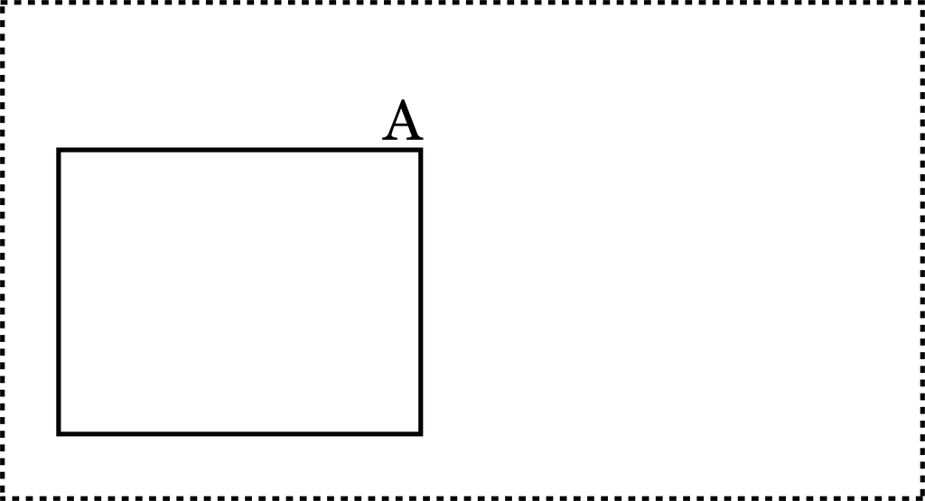

## Venn Diagrams for Probability

The probability of an event is represented by the proportion of the area of the outer rectangle it takes up.

What do you think the probability of $A$ is below?

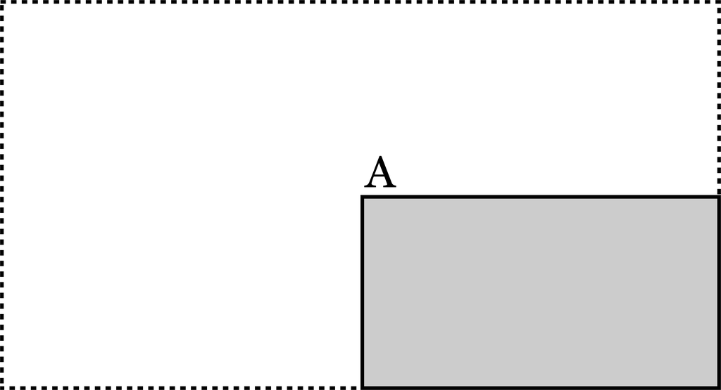

## Disjoint Events

In a Venn diagram, two events are disjoint if their rectangles don’t overlap.

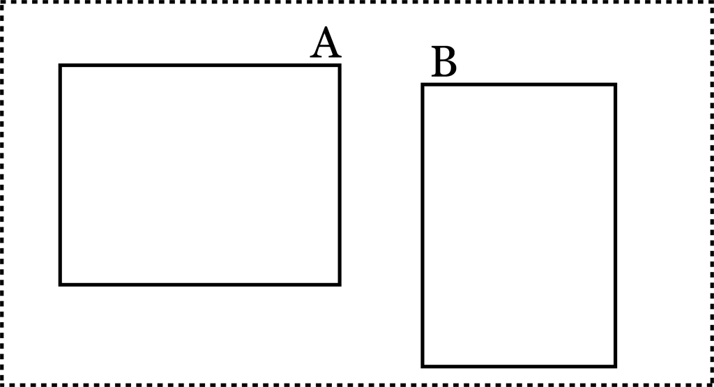

## Probability Rules and Venn Diagrams

We can use Venn diagrams to visualize probability rules. For example, the general additive rule:

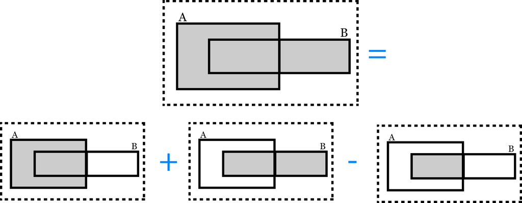

# Conditional Probability

## The Concept of Conditioning

Consider the following questions:

1. Before a game of American football, the home team had a 75% chance to win the game. At half time, the away team leads by 3 points. How does this change the probability that the home team wins?
2. The weather forecast yesterday gave a 40% chance of rain in the morning. At 8 AM, you see that the sky is totally clear. Given this, what now is the probability of rain this morning?

These are questions about **conditional probabilities**, the probability of one event given that we know another event has happened.

## Conditional Probability Visually

The following Venn diagram shows the events that it rains in the morning and that it’s clear at 8 AM. The probability of it raining in the morning is shown in grey.

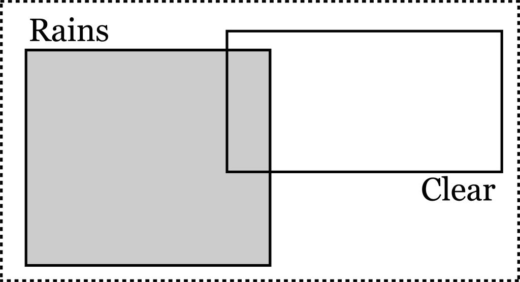

## Conditional Probability Visually

The dashed rectangle represents all possible outcomes. We represent learning that it is clear at 8 AM by making the rectangle for “Clear” the dashed rectangle, showoing that everything outside of the “Clear” rectangle is now impossible.

[figure not shown]

## Conditional Probability Visually

**Discussion Question**

Using this Venn diagram, what rectangle represents the event that it rains given that it’s clear at 8 AM? How would you calculate the probability of it raining given that it’s clear at 8 AM?

[figure not shown]

## Conditional Probability Visually

**This is the same way we represented probabilities in Venn diagrams before, but the dashed rectangle has changed to represent the information we have.**

## Conditional Probability Formula

The Venn diagram tells us exactly how to write down a formula for conditional probability.

## Conditional Probability Formula

Ratio of rectangle areas:
$$P(\text{Rain and Clear}) / P(\text{Clear})$$

## Conditional Probability Formula

**Definition: Conditional Probability**

Let $A$ and $B$ be events. If $P(B)>0$, the conditional probability of $A$ given $B$ is written as $P(A\mid B)$ (with a vertical line), and is defined as
$$P(A\mid B) = \frac{P(A\text{ and } B)}{P(B)}.$$

## Vocabulary

Now that we have more types of probabilities floating around, it is useful to give different names to different probabilities.

**Definition: Marginal and Joint Probabilities**

When we have two events $A$ and $B$, the probabilities $P(A)$ and $P(B)$ of either separately are called the **marginal probabilities**. The probability $P(A\text{ and }B)$ of both events happening is called the **joint probability**.

## The General Multiplication Rule

If we flip the definition of conditional probability around, we get the following rule.

**Definition: General Multiplication Rule**

For any two events $A$ and $B$, the **general multiplication rule** says that we can write their joint probability as the conditional probability of one times the marginal probability of the other:

$$P(A\text{ and }B) = P(A\mid B)P(B) = P(B\mid A)P(A).$$

## Independent Events

Sometimes one event tells us absolutely nothing about another event. In this case we say that the two events are independent.

**Definition: Independence**

Two events $A$ and $B$ are **independent** if either of the following conditions is true:

1. $P(A\mid B) = P(A)$
2. $P(B\mid A) = P(B)$

**Example:** You are flipping two coins. If $A = \{\text{First coin heads}\}$ and $B = \{\text{Second coin heads}\}$, then $A$ and $B$ are independent. The first coin coming up heads is unrelated to the second coin comes up heads. Specifically, the probability that the second coin comes up heads is 50% regardless of whether the first coin comes up heads.

## The *Non-General* Multiplication Rule

**Definition: The Multiplication Rule**

Suppose $A$ and $B$ are independent events.

The general multiplication rule says that $P(A\text{ and }B) = P(A\mid B)P(B)$. But the definition of independence tells us that $P(A\mid B) = P(A)$. Combining these two facts gives the **multiplication rule**, which says that when $A$ and $B$ are independent, their joint probability is the product of their marginal probabilities:

$$P(A\text{ and }B) = P(A)P(B).$$

## Independent and Disjoint Events

**Discussion Question**

If events $A$ and $B$ are disjoint, are they also independent? Can you explain your answer in both English and using math?

**Answer: No**

In English: If $A$ and $B$ are disjoint, and we find out that $A$ happens, then we no for sure that $B$ *cannot happen*. Therefore $A$ is very informative about $B$, so $A$ and $B$ are not independent.

In Math: If $A$ and $B$ were independent and disjoint, then by the multiplication rule
$$0 = P(A\text{ and }B)=P(A)P(B),$$

which can only be true if $P(A) = 0$ or $P(B) = 0$.

# Probability Distributions

## Distribution of a Random Process

Suppose that a random process produces possible outcomes $x_1,x_2,\ldots,x_n$.

**Definition: Probability Distribution**

The **probability distribution** of a random process with $n$ outcomes is just the collection of probabilities for each outcome:

$$P(\{\text{get outcome } x_i\}) \text{ for } i = 1,2,\ldots, n.$$

## Familiar Examples

Examples of random processes:

- Result of flipping a coin ($n=2$ outcomes)
- Numbers rolled on two dice ($n = 36$ outcomes)

In these examples, all outcomes are equiprobable, so
$$P(\{\text{get outcome } x_i\}) = \frac{1}{n},$$

for all outcomes. In this case, we say the distribution of the process is **uniform**.

## A Caution

**Defining Random Processes**

In the previous examples of random processes, we specified not only what was *done* (flipping a coin, rolling dice), but also what was *measured* (which side of the coin we got, what the two numbers on the dice were). This is important because otherwise we can get confused about what the outcomes $x_1,x_2,\ldots, x_n$ should be.

## More Complex Distributions

Not all probability distributions are uniform.

Consider the random process: “Flip two coins and count the number of heads.”

**Discussion Question**

What are the outcomes for this random process?

**Discussion Question**

What is the probability distribution of this random process? (You should calculate a probability for each outcome.)

## Distributions for Continuous Processes

Some random processes don’t have a finite number of possible outcomes.

Example: The time is takes you to get to your next class.

When the outcomes are continuous, we can’t count outcomes to calculate
$$P(\{\text{get outcome }x\})$$

for the infinitely many possible $x$.

## Distributions for Continuous Processes

In fact, we have a bigger problem.

Recall: In continuous data, usually no value occurs exactly twice

For anty possible outcome $x$ of a con†inuous random process:
$$P(\{\text{get exactly } x\}) = 0.$$

## Distributions for Continuous Processes

However, we can still talk about probabilities of ranges.

Suppose $x_1$ and $x_2$ are two possible outcomes of a continuous process, then

$$P(\{x_1 \leq \text{ outcome }\leq x_2\}) > 0.$$

Example: Can ask for the probability that it takes 4 – 5 minutes for you to get to your next class.

## Distributions for Continuous Processes

**Problem:** For processes with finite outcomes $x_1,\ldots,x_n$, we described the distribution by just listing out all probabilities $P(\{\text{get outcome } x_i\})$. For a continuous process, how do we list out probabilities of all ranges $P(\{x_1 \leq \text{ outcome }\leq x_2\})$?

## Return to Histograms

**Simpler problem:** If we have a dataset with a continuous variable, how would we estimate the probability of an outcome being in some range?

**Discussion Question**

If we track the time it takes students to get from one class to another at Wake Forest, how would we estimate the probability that it takes a randomly chosen student longer than 5 minutes to get to their next class?

## Return to Histograms

**Discussion Question**

If I didn’t give you the raw data and only showed you a histogram of the time is takes students to get to their next class, how would you estimate the probability that it takes longer than 5 minutes for a randomly chosen student?

Sketch a histogram for what you think this data might looks like and try to represent this probability visually. Make the bins of your histogram each 1 minute long.

## Return to Histograms

**Discussion Question**

Now what if I asked you to use your histogram to estimate the probability that it takes longer than $5.5$ minutes to get to the next class? Is that harder? Why or why not?

## From Histograms to Densities

Conclusions so far:

1. We can estimate probabilities of landing in some range by adding up bin heights in histograms.
2. This process is imperfect if the range we care about does not line up with the edges of our bins.

**Idea:** If we get even more data, we could reduce this problem by making the bins of our histogram narrower, getting more bins, and increasing our resolution to estimate probabilities of ranges.

## From Histograms to Densities

That process might looks like this:

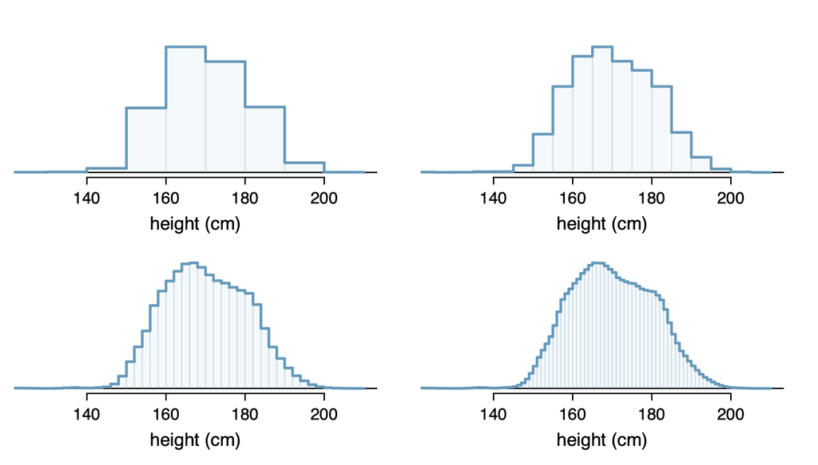

Adults Heights in US

## Probability Density Curves

**Definintion: Probability Density**

A **probability density** is a curve which describes the distribution of outcomes for a continuous random process, where the $x$ axis consists of all possible (continuous) outcomes. The probability of getting an outcome in any range $x_1$ to $x_2$ is the area under the probability density curve between $x_1$ and $x_2$.

We can think of probability densities as being like histograms with infinitely many bins (or, equivalently, infinitely narrow bins).

## Probability Density Curves

For the adult height example, the density might look like this:

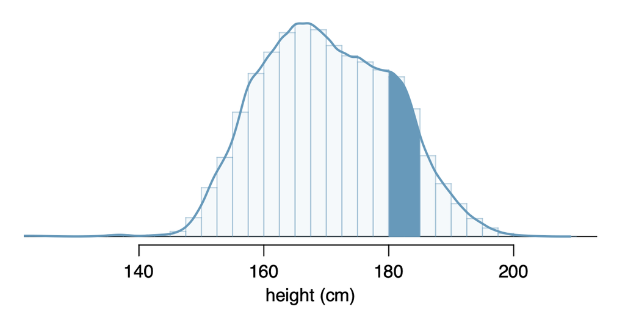

Density of Adult Heights in US Population